# Dynamic Visualization using Shiny

Motivating question: In statistics, you learned that when we sample, we want large sample sizes. *Why?*

Let’s see this in practice. If we drew $k = 2000$ random samples of size $n = 2$, $n = 10$, and $n = 50$, respectively, we would get three sampling distributions. We could then visualize each sampling distribution with a plot:

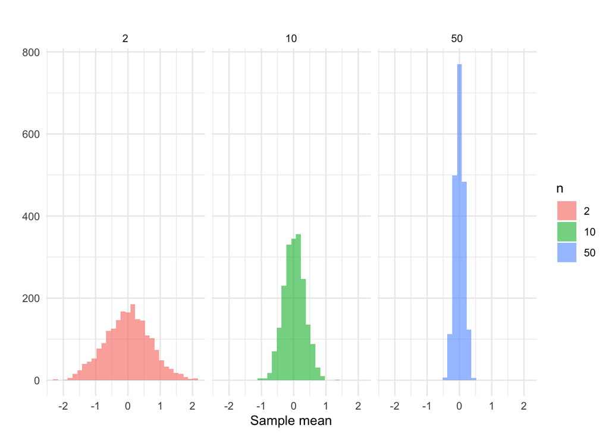

Take a look at each plot. What is the visualization showing you? By displaying this information visually, what do you learn?

Now, take a look at a different way of using a visualization to convey this point: [visualization of sampling distributions](https://jacobtnyoung.shinyapps.io/sampling-distributions/).

## Static vs. Dynamic Visualization

The visualizations above are examples of static and dynamic visualizations, respectively. What makes the latter visualization *dynamic* is that the user can alter the inputs to change what the visualization shows. It is not simply fixed by the author/developer/etc, it is interactive: the **user** is able to alter what is *rendered*.

## Other examples…

What if you were interested in:

- identifying an optimal strategy for network disruption (check out this [network disruption app](https://jacobtnyoung.shinyapps.io/network-disruption/))
- trends in faculty pay (check out this [ASU CCJ faculty salary dashboard](https://jacobtnyoung.shinyapps.io/sccj-faculty-salary-dashboard/))
- collecting network data (check out this [network data collection tool](https://jacobtnyoung.shinyapps.io/probation-pilot-app/))
- the spatial distribution of crime in Phoenix (check out this [Phoenix Crime Dashboard](https://jacobtnyoung.shinyapps.io/crime-in-phx/))

These are all built using [Shiny](https://shiny.posit.co/)!

# What is Shiny and How it Works

Shiny is an R framework for building interactive web applications directly from R code. It allows you to take static analyses and visualizations, like a `ggplot`, and turn them into user-driven applications that run in a web browser.

With Shiny, users can:

- Adjust inputs (sliders, dropdowns, buttons)
- Filter data
- Change model parameters
- Instantly see updated visualizations and results

## Core Concepts

Shiny apps are built around three simple ideas:

- The UI (User Interface), which is what the user sees. It includes the layout of the page, input controls (sliders, dropdowns, checkboxes), and output placeholders (where plots, tables, or text will appear). The UI defines the structure of the app.
- The Server, this is what happens behind the scenes. It is where we put the instructions for what is produced in the UI, where data is processed, and where calculations happen. The server connects user inputs to outputs.
- Reactivity is what makes Shiny dynamic (and powerful). Reactivity means that code reruns automatically when inputs change. Think of it like Excel cell recalculation: If one cell changes, any dependent cells update automatically. Shiny works the same way in that changes to the inputs trigger update which refresh the output.

Let’s go back to the [visualization of sampling distributions](https://jacobtnyoung.shinyapps.io/sampling-distributions/) app and take a closer look. Now, take a closer look “under the hood” to see what it looks like [here](https://github.com/jacobtnyoung/dynamic-viz/blob/main/apps/sampling/app.R).

## An Example

### Static Visualization

Suppose we created a plot using this code:

```r
library( ggplot2 )

n <- 100

x <- rnorm( n )

ggplot(data.frame(x = x), aes(x = x)) +
      geom_histogram(bins = 30, fill = "steelblue", alpha = 0.7) +
      labs(title = paste("Histogram of", n, "random normals"),
           x = "value", y = "count") +
      theme_minimal()
```

[output not shown]

We have a very simple plot of random draws from a standard normal distribution. What if we wanted to increase the number we took? Decrease it?

### Dynamic Visualization

Let’s create a very simple Shiny app. As we do this, ask yourself: What is part of the UI? What is part of the server? Where is reactivity happening?

To get started, create a new R script file and add this code to it:

```r
# use these commands to install the packages
# install.packages( "shiny" )
# install.packages( "ggplot2" )

library( shiny )
library( ggplot2 )

ui <- fluidPage(
  titlePanel("Interactive Histogram"),
  sidebarLayout(
    sidebarPanel(
      sliderInput("n", "Sample size (n):", min = 10, max = 1000, value = 100, step = 10)
    ),
    mainPanel(
      plotOutput("hist")
    )
  )
)

server <- function(input, output) {
  output$hist <- renderPlot({
    x <- rnorm(input$n)
    ggplot(data.frame(x = x), aes(x = x)) +
      geom_histogram(bins = 30, fill = "steelblue", alpha = 0.7) +
      labs(title = paste("Histogram of", input$n, "random normals"),
           x = "value", y = "count") +
      theme_minimal()
  })
}

shinyApp(ui = ui, server = server)
```

Ok, you just created your first Shiny app! I knew you had it in you. Let’s walk through what we did.

The first part loads the libraries to get the functions needed to build the app and the plot:

```r
library( shiny )
library( ggplot2 )
```

Next, we have our two key pieces, the `ui` and the `server`. Let’s look at the code for defining the user interface:

```r
ui <- fluidPage(
  titlePanel("Interactive Histogram"),
  sidebarLayout(
    sidebarPanel(
      sliderInput("n", "Sample size (n):", min = 10, max = 1000, value = 100, step = 10)
    ),
    mainPanel(
      plotOutput("hist")
    )
  )
)
```

We are first defining an object called `ui` which will define the user interface. Look at your app and see what the user side features are. Can you find them in the code?

We start the user interface with the `fluidPage()` function. Inside this function we have `titlePanel()` which gives the title.

We then we have `sidebarLayout()` which prepares the sidebar. Inside the sidebar layout we have `sidebarPanel()` that has `sliderInput()` inside it. What does this line do? Look at the app and think about what is happening.

Finally, we have the `mainPanel()` function with the `plotOutput()` function designating an object `"hist"` to be plotted.

Now, let’s examine the server side:

```r
server <- function(input, output) {
  output$hist <- renderPlot({
    x <- rnorm(input$n)
    ggplot(data.frame(x = x), aes(x = x)) +
      geom_histogram(bins = 30, fill = "steelblue", alpha = 0.7) +
      labs(title = paste("Histogram of", input$n, "random normals"),
           x = "value", y = "count") +
      theme_minimal()
  })
}
```

We define a **function** called `server` which is going to be our workhorse. It is going to take an `input` that the user can alter in the UI. Anytime a change is made by the user, this is going to pass through our server object and change what is rendered in `output`.

Remember that we defined an object called `"hist"` in UI using `plotOutput()`. Here we are defining what that will be. Specifically, we use the `renderPlot()` function. This is getting a bit more complicated, so let’s take each line:

- `x <- rnorm(input$n)` creates an object `x`, which is a random draw from a normal distribution, `rnorm`, where the size is defined by the user with `input$n`. Look back to the UI, where do you see `"n"`? **Look at what we just did**: we built into our plot function the changes that are being made by the user in the UI. This is called a **reactive value**.
- `ggplot(data.frame(x = x), aes(x = x)) +`… defines a plot object, using `ggplot()`, that is based on the `x` object.

And that is really it. Much of the code is tweaking the `ggplot` object.

Now for our last piece:

```r
shinyApp(ui = ui, server = server)
```

Here, we are just running the `shinyApp()` function and defining the arguments that function needs to operate: the UI and the server.

#### Functions

As you can see, there are a number of functions that we use to build the app. You can browse the functions that are build in `shiny` by typing `help( package = "shiny" )`. There are also many extensions that have been written:

- [shiny widget gallery](https://shiny.posit.co/r/gallery/widgets/widget-gallery/)
- [shinyWidgets](https://dreamrs.github.io/shinyWidgets/)
- awesome-shiny-extensions

# Using AI to Build Shiny Apps

Now that we understand how Shiny works (i.e. UI, server, and reactivity), we can start building more complex apps. This is where AI becomes a very useful tool. Instead of writing everything from scratch, we can use AI to help generate are basic idea, suggest improvements, and help debug issues.

## Bad Prompts vs. Good Prompts

Try this example prompt: “create a Shiny dashboard.” Now, let’s see what it produced and think about these questions:

- what is missing?
- why is it generic?
- what assumptions did it make?

Now, try this prompt: “Create a Shiny app using the mtcars dataset with. It should include a dropdown to select a variable, a scatterplot of mpg vs selected variable, a summary table below the plot, a sidebar layout, and beginner-friendly code with comments”.

*How is this one different?*

### Strong Prompt Structure

A good prompt gives the algorithm needed information for making decisions about what it generates. A strong prompt will:

- Identify a dataset or describe the data that needs to be created
- Inputs that the user can adjust (e.g., a slider)
- Outputs that are the consequence of user adjustments (e.g., a plot)
- Layout instructions
- Constraints such as “use this specific package” or “don’t use additional packages” or “add instructions”

An example prompt template might look something like this: “Build a Shiny app in R using [dataset]. Include [inputs]. Display [outputs]. Use [layout type]. Write clean, commented, beginner-friendly code.”

## Debugging

Another major strength of AI as a helper is that it is great at debugging code. To illustrate, let’s take a look through the following code chunk:

```r
library(shiny)
library(ggplot2)

ui <- fluidPage(
  titlePanel("Simple Scatterplot")
  sidebarLayout(
    sidebarPanel(
      selectInput("var", "Choose a variable:",
                  choices = names(mtcars))
    ),
    mainPanel(
      plotOutput("scatterPlot")
    )
  )
)

server <- function(input, output, session) {

  output$scatter <- renderPlot({

    x_var <- mtcars[[input$variable]]

    ggplot(data.frame(x = x_var, y = mtcars$mpg),
           aes(x = x, y = y)) +
      geom_point(color = steelblue, size = 3) +
      theme_minimal() +
      labs(x = input$variable,
           y = mpg)

  })

}

shinyApp(ui = ui, server = server)
```

Open an R script file and try seeing if you can find the errors.

Here is the debugged code:

```r
library(shiny)
library(ggplot2)

ui <- fluidPage(
  titlePanel("Simple Scatterplot"), # note that we were missing a comma
  sidebarLayout(
    sidebarPanel(
      selectInput("variable", "Choose a variable:", # above, our Input ID is mismatched
                  choices = names(mtcars),
                  selected = "wt")
    ),
    mainPanel(
      plotOutput("scatter") # above, this output name was mismatched
    )
  )
)

server <- function(input, output, session) {

  output$scatter <- renderPlot({

    x_var <- mtcars[[input$variable]]

    ggplot(data.frame(x = x_var, y = mtcars$mpg),
           aes(x = x, y = y)) +
      geom_point(color = "steelblue", size = 3) + # above we were missing ""s for this
      theme_minimal() +
      labs(x = input$variable,
           y = "mpg") # same problem here with missing ""s

  })

}

shinyApp(ui, server)
```

Now that we understand how to use AI, let’s build something ourselves and use AI as an assistant.

## Exercise

Think about an app you would like to build. What would it show? What would it allow the user to do? What is the learning goal? Now, having conjured these thoughts, develop a prompt to generate a basic setup for your app.

# Q&A and Extensions

This is only scratching the surface. You can build very elaborate apps. For example, check out this app designed to teach about [linear regression](https://shiny.posit.co/r/gallery/education/didacting-modeling/).

If you are interested in reading up on it, here are some really good FREE books:

- [Mastering Shiny](https://mastering-shiny.org/index.html) is the first stop for moving forward with learning how to use Shiny.
- [Unleash Shiny](https://unleash-shiny.rinterface.com/) and [Engineering Shiny](https://engineering-shiny.org/index.html) are great next steps for creating awesome apps.

There is also an annual conference, [ShinyConf](https://www.shinyconf.com/), where developers discuss their work. There are also awards for best apps. Here is a gallery of the [2024 winners](https://posit.co/blog/winners-of-the-2024-shiny-contest/).

John Tukey once said, “The greatest value of a picture is when it forces us to notice what we never expected to see.”